# R Programming: Take Home MidTerm

Denis Vrdoljak

Dec 4, 2019

QUESTION 1

Complete the following questions, then submit this R Notebook with your work on Camino.

Load the data in the file “fillna.txt”, replace the NA’s with “unknown” and save to a new file called “cleaned.txt”

```r
## Student code goes here
#set a wd
data = read.table("fillna.txt")
data[is.na(data)] <- "unknown"
head(data)
```

```
   V1      V2 V3      V4
1 100       1  1       1
2 200       2  2       2
3 300       3  3       3
4 400       4  4       4
5 500 unknown  5 unknown
6 600 unknown  6       6
```

```r
write.table(data, file = "cleaned.txt", row.names = FALSE, col.names = FALSE)
## Student code goes here
```

QUESTION 2

Load the table fillna.txt and a) create a vector of NA counts by column b) create a vector of NA counts by row

```r
## Student code goes here
mydata = read.table("fillna.txt")
count_col_na <- colSums(is.na(mydata))
print("Vector of NA counts by column: ")
```

```
[1] "Vector of NA counts by column: "
```

```r
count_col_na
```

```
V1 V2 V3 V4
 0  2  0  1
```

```r
count_row_na <- rowSums(is.na(mydata))
print("Vector of NA counts by row: ")
```

```
[1] "Vector of NA counts by row: "
```

```r
count_row_na
```

```
[1] 0 0 0 0 2 1
```

```r
## Student code goes here
```

QUESTION 3

Load the mtcars dataset, and show the structure of the table.

```r
## Student code goes here
data("mtcars")
str(mtcars)
```

```
'data.frame':   32 obs. of  11 variables:
 $ mpg : num  21 21 22.8 21.4 18.7 18.1 14.3 24.4 22.8 19.2 ...
 $ cyl : num  6 6 4 6 8 6 8 4 4 6 ...
 $ disp: num  160 160 108 258 360 ...
 $ hp  : num  110 110 93 110 175 105 245 62 95 123 ...
 $ drat: num  3.9 3.9 3.85 3.08 3.15 2.76 3.21 3.69 3.92 3.92 ...
 $ wt  : num  2.62 2.88 2.32 3.21 3.44 ...
 $ qsec: num  16.5 17 18.6 19.4 17 ...
 $ vs  : num  0 0 1 1 0 1 0 1 1 1 ...
 $ am  : num  1 1 1 0 0 0 0 0 0 0 ...
 $ gear: num  4 4 4 3 3 3 3 4 4 4 ...
 $ carb: num  4 4 1 1 2 1 4 2 2 4 ...
```

```r
## Student code goes here
```

QUESTION 4 Load the airquality dataset and show the first 7 rows. (PART A)

```r
## Student code goes here
data("airquality")
head(airquality,7)


## Student code goes here
```

[output not shown]

… and show the last 4 rows of data (PART B)

```r
## Student code goes here
tail(airquality,4)
```

```
    Ozone Solar.R Wind Temp Month Day
150    NA     145 13.2   77     9  27
151    14     191 14.3   75     9  28
152    18     131  8.0   76     9  29
153    20     223 11.5   68     9  30
```

```r
## Student code goes here
```

Show data for the month of May (PART C)

```r
## Student code goes here
library("dplyr")
mayData <- airquality %>%
  filter(Month == 5)
mayData
```

```
   Ozone Solar.R Wind Temp Month Day
1     41     190  7.4   67     5   1
2     36     118  8.0   72     5   2
3     12     149 12.6   74     5   3
4     18     313 11.5   62     5   4
5     NA      NA 14.3   56     5   5
6     28      NA 14.9   66     5   6
7     23     299  8.6   65     5   7
8     19      99 13.8   59     5   8
9      8      19 20.1   61     5   9
10    NA     194  8.6   69     5  10
11     7      NA  6.9   74     5  11
12    16     256  9.7   69     5  12
13    11     290  9.2   66     5  13
14    14     274 10.9   68     5  14
```

[output cut: 17 more lines]

```r
## Student code goes here
```

QUESTION 5

Load the Orange dataset, and perform the following analyses. Organize your work and present your answers with separate R Notebook cells.

** STUDENT CODE CELLS SHOULD GO HERE. Create your own cells! **

Load the Orange dataset, and perform the following analyses. Organize your work and present your answers with separate R Notebook cells.

```r
#downloading dataset
data("Orange")
#showing data
head(Orange)
```

```
  Tree  age circumference
1    1  118            30
2    1  484            58
3    1  664            87
4    1 1004           115
5    1 1231           120
6    1 1372           142
```

1. Do a simple scatterplot of Age vs circumference.

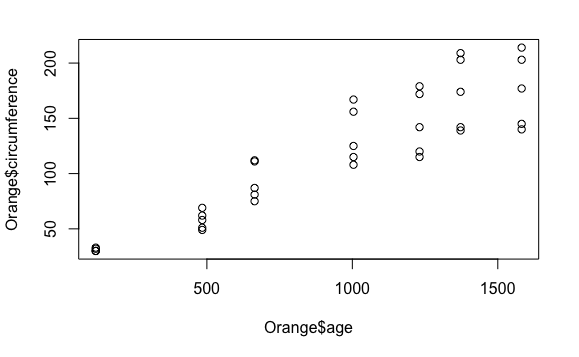

```r
plot(Orange$age,Orange$circumference)
```

```r
NA
```

2. Make a stripchart of age

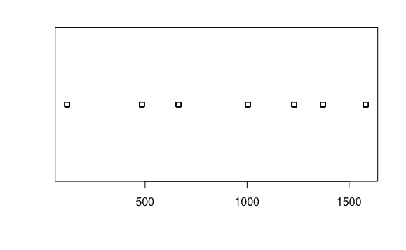

```r
stripchart(Orange$age)
```

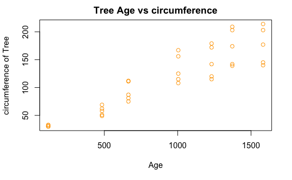

```r
plot(Orange$age, Orange$circumference,
     main = "Tree Age vs circumference",
     xlab = "Age",
     ylab = "circumference of Tree",
     col  = "orange")
```

QUESTION 6 Using the Orange Dataset again, create a graph that shows the distribution of values of the circumference column

```r
## Student code goes here
x <- Orange$circumference
h<-hist(x, breaks=25, xlab="Circumference",
   main="Distribution of the Circumference")
xfit<-seq(min(x),max(x),length=40)
yfit<-dnorm(xfit,mean=mean(x),sd=sd(x))
yfit <- yfit*diff(h$mids[1:2])*length(x)
lines(xfit, yfit, col="blue", lwd=2)
```

[figure not shown]

```r
lines(density(Orange$circumference), col="blue", lwd=2)
```

```r
## Student code goes here
```